# Given names

Florian Gaudin-Delrieu

21 mars 2016

## About

The idea is to study the data about given names from wikipedia.org, and in particular, what are the occupations of people with that given name. It turns out that scrapping wikipedia, getting the first names and the occupation would be difficult, as the data is unstructured. Hopefully, the [wikidata project](http://wikidata.org) exists. It gives access to structured data, so we will use that to get the informations we want.

```r
library(ggplot2)
library(WikidataR)
library(dplyr)
library(tidyr)
library(magrittr)
library(ggthemes)
library(plotly)
library(SPARQL)
library(wordcloud)
library(stringr)
theme_set(theme_minimal(12))
```

## Retrieving informations

We will get the item reference to the given name we want to study (it starts by a Q and is not meaningful). Then we can use that item to feed a SPARQL query that will give us the dataset.

### Getting the item id

```r
liste <- find_item("Florian") #Limit is set by default to 10 results, it should be enough here.
liste
```

```
##
##  Wikidata item search
##
## Number of results:    10
##
## Results:
## 1     Florian (Q937379) - given name
## 2     Florian (Q115707) - Wikipedia disambiguation page
## 3     Stanisław Marek Rzętkowski (Q17376084) - Polish poet, playwright, journalist and translator.
## 4     Florian (Q22075377)
## 5     Florian (Q5460987)
## 6     Efraim Frisch (Q1296459) - German writer
## 7     Florianne (Q18177255) - female given name
## 8     Florian Monreal (Q23900195) - cyclist
## 9     Florian Moser (Q20934571)
## 10    Florian Nowak (Q22681825) - cyclist
```

Now we have a list with 10 results, and we want to extract the id of the first entry with “given name”, or the first entry. I wrapped these steps into a function.

```r
selectionnerID<-function(nom){
  liste <- find_item(nom)
  id <-""
  for(i in 1:length(liste)){
    if(is.null(liste[[i]]$description)){
      next
    }
    if(grepl("given name",liste[[i]]$description)){
      id <- liste[[i]]$id
        break # we break on the first given name we find
    }
  }
  # If we haven't found given name, then we take the first id
  if(id==""){
    id<-liste[[1]]$id
  }
  return(id)
}
id<-selectionnerID("Florian")
get_item(id) #Sanity check
```

```
##
##  Wikidata item Q937379
##
## Label:        Florian    [82 other languages available]
## Aliases:  Florian, Floriaan, Kwiatosław, Tworzyjan, Florian (given name), Florian (first name)
## Description: given name  [10 other languages available]
## Claims:       7
## Sitelinks:    12
```

### Modifying the query

We will query wikidata with a query I came up with, and modifying the given name id we got. The place where to replace is given by **REPLACE_ID**, so that’s what we will be looking for to replace.  
The parameters are :

- **P735** for given name
- **P106** for occupation
- **P569** for the date of birt
- **P27** for the country
- Labels are the french ones, with a fallback in english.

You can find the parameters code using `find_property("parameter")` from WikidataR.

```r
endpoint <- "https://query.wikidata.org/bigdata/namespace/wdq/sparql"
#endpoint <- "https://query.wikidata.org/sparql"

prefix<-c("wd","<http://www.wikidata.org/entity/>",
          "wdt", "<http://www.wikidata.org/prop/direct/>",
          "wikibase","<http://wikiba.se/ontology#>")

generic_query <-"SELECT ?item ?itemLabel ?occupationLabel ?paysLabel ?annee
WHERE
{
?item wdt:P735 wd:REPLACE_ID .
?item wdt:P106 ?occupation .
OPTIONAL {?item wdt:P569 ?anneeN} .
OPTIONAL {?item wdt:P27 ?pays} .
BIND(YEAR(?anneeN) as ?annee) .
SERVICE wikibase:label { bd:serviceParam wikibase:language \"fr,en\" }
}
ORDER BY DESC (?annee)"

query<-sub("REPLACE_ID",id,generic_query)
```

### Executing the request

We will use the SPARQL library to get the dataset.

```r
source("mySPARQL.R")
res <- mySPARQL(endpoint,query,ns=prefix,format = "xml")
resultats<- res$results
summary(resultats)
```

```
##      item            itemLabel         occupationLabel
##  Length:809         Length:809         Length:809
##  Class :character   Class :character   Class :character
##  Mode  :character   Mode  :character   Mode  :character
##
##
##
##
##   paysLabel             annee
##  Length:809         Min.   :1480
##  Class :character   1st Qu.:1954
##  Mode  :character   Median :1974
##                     Mean   :1953
##                     3rd Qu.:1983
##                     Max.   :2000
##                     NA's   :29
```

```r
glimpse(resultats)
```

```
## Observations: 809
## Variables: 5
## $ item            (chr) "wd:Q1429707", "wd:Q1429707", "wd:Q15428646", ...
## $ itemLabel       (chr) "\"Florian Hartung\"@fr", "\"Florian Hartung\"...
## $ occupationLabel (chr) "\"scénariste\"@fr", "\"producteur de cinéma\"...
## $ paysLabel       (chr) "\"Allemagne\"@fr", "\"Allemagne\"@fr", "\"Aut...
## $ annee           (int) 2000, 2000, 2000, 2000, 2000, 2000, 2000, 2000...
```

### Cleaning the data

We need to format the data we got. The selectionnerNom function will fetch the middle part of the returned column, which is in the form `"GivenName LastName"@fr`. So we will apply this function to the “labels” columns (itemLabel, occupationLabel and paysLabel), and then convert those columns to factors.

```r
selectionnerNom<-function(x,colonne,nom) {
  a<-x %>%
    separate_(colonne,c("debut",nom,"fin"),sep="\"",remove=TRUE) %>%
    select(-debut,-fin)
  a[,nom]<-factor(a[,nom])
  return(a)
}

resultats<-selectionnerNom(resultats,"itemLabel","nom")
resultats<-selectionnerNom(resultats,"occupationLabel","metier")
resultats<-selectionnerNom(resultats,"paysLabel","pays")
resultats<-tbl_df(resultats)
resultats
```

```
## Source: local data frame [809 x 5]
##
##            item               nom               metier      pays annee
##           (chr)            (fctr)               (fctr)    (fctr) (int)
## 1   wd:Q1429707   Florian Hartung           scénariste Allemagne  2000
## 2   wd:Q1429707   Florian Hartung producteur de cinéma Allemagne  2000
## 3  wd:Q15428646    Florian Boesch      artiste lyrique  Autriche  2000
## 4  wd:Q15445413    Florian Seiler   historien de l'art Allemagne  2000
## 5  wd:Q15445413    Florian Seiler          archéologue Allemagne  2000
## 6  wd:Q15726644    Florian Beqiri             chanteur   Albanie  2000
## 7  wd:Q15809847    Florian Trèves        sauteur à ski    France  2000
## 8  wd:Q22211275 Florian Goutiéras               acteur    France  2000
## 9  wd:Q18215072   Florian Latorre    pilote automobile    France  1997
## 10 wd:Q20894637     Florian Faber               archer        NA  1997
## ..          ...               ...                  ...       ...   ...
```

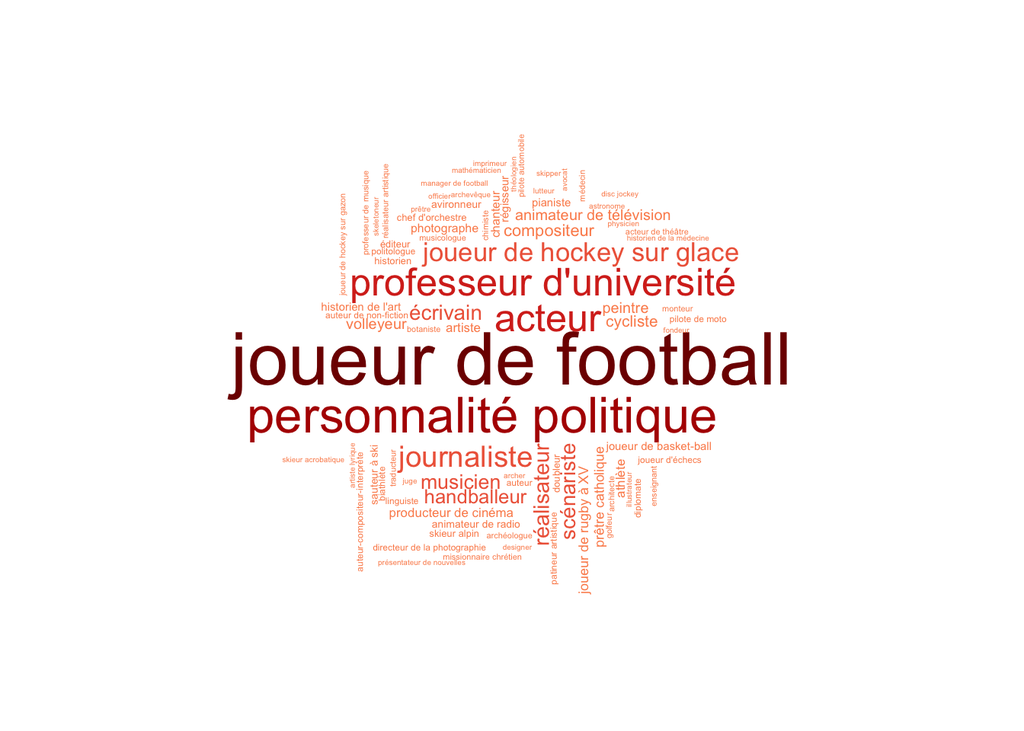

```r
library(wordcloud)
tousLesMetiers<-resultats %>%
  group_by(metier) %>%
  count(metier)

set.seed(1)
wordcloud(tousLesMetiers$metier,tousLesMetiers$n,scale=c(3,0.25),min.freq=2,colors=brewer.pal(9,"OrRd")[c(5,6,7,8,9)],random.order = FALSE,rot.per=0.3)
```

Some descriptions are quite long, and sometimes the most occuring profession wouldn’t fit on the wordcloud. I made the function that adds a newline character near the middle of the descriptions, if there is a space or a dash.

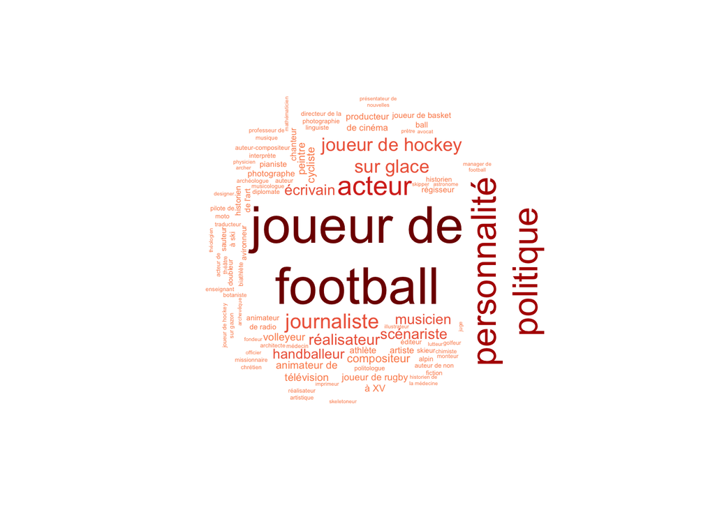

```r
couperMot<-function(mot){
  #coupe une chaine de caractère sur l'espace le plus proche du milieu
  z=as.character(mot)
  mi=ceiling(str_length(z)/2)
  a<-str_locate_all(z,"[ -]")[[1]]
  if (length(a)==0){ #S'il n'y a pas d'espace ou tiret
    return(z)
  }
  else { #on prend le premier espace après le milieu
    b<-a[(a-mi>0)[,1],1][1]
    if (length(b)==0){ #Si les espaces ou tiret sont avant le mileu
      b<-a[1,1]
    }
    str_sub(z,b,b)<-"\n"
    return(z)
  }
}
tousLesMetiers$new<-mapply(couperMot,tousLesMetiers$metier)
wordcloud(tousLesMetiers$new,tousLesMetiers$n,scale=c(3,0.25),min.freq=2,colors=brewer.pal(9,"OrRd")[c(5,6,7,8,9)],random.order = FALSE,rot.per=0.3)
```

```r
gettingData<-function(prenom){
  id<-selectionnerID(prenom)

  #Building the query
  endpoint <- "https://query.wikidata.org/bigdata/namespace/wdq/sparql"

  prefix<-c("wd","<http://www.wikidata.org/entity/>",
            "wdt", "<http://www.wikidata.org/prop/direct/>",
            "wikibase","<http://wikiba.se/ontology#>")

  generic_query <-"SELECT ?item ?itemLabel ?occupationLabel ?paysLabel ?annee
  WHERE
  {
  ?item wdt:P735 wd:REPLACE_ID .
  ?item wdt:P106 ?occupation .
  OPTIONAL {?item wdt:P569 ?anneeN} .
  OPTIONAL {?item wdt:P27 ?pays} .
  BIND(YEAR(?anneeN) as ?annee) .
  SERVICE wikibase:label { bd:serviceParam wikibase:language \"fr,en\" }
  }
  ORDER BY DESC (?annee)"

  query<-sub("REPLACE_ID",id,generic_query)

  #Getting te data
  results<-mySPARQL(endpoint,query,ns=prefix,format = "xml")$results

  #Cleaning the data
  results<-selectionnerNom(results,"itemLabel","nom")
  results<-selectionnerNom(results,"occupationLabel","metier")
  results<-selectionnerNom(results,"paysLabel","pays")

  return(results)
}

occupationWordcloud<-function(results){
  everyOccupation<-results %>%
    group_by(metier) %>%
    count(metier)
  everyOccupation$occ<-mapply(couperMot,everyOccupation$metier)
  set.seed(14)
  wordcloud(everyOccupation$occ,everyOccupation$n,
            scale=c(3,0.25),min.freq=2,
            colors=brewer.pal(6,"Dark2"),
            random.order = FALSE,rot.per=0.3)
}

occupationGraph<-function(results){
  prenom<-word(results$nom[1])
  ggplotly(ggplot(results %>% distinct(item),aes(x=annee))+
    geom_histogram(binwidth = 10,aes(fill=pays))+
    ggtitle(paste("Répartition des", prenom,"dans Wikidata"))+
    ylab("Nombre")+
    xlab("Année de naissance"))
}
```

```r
florian<-gettingData("Florian")
```

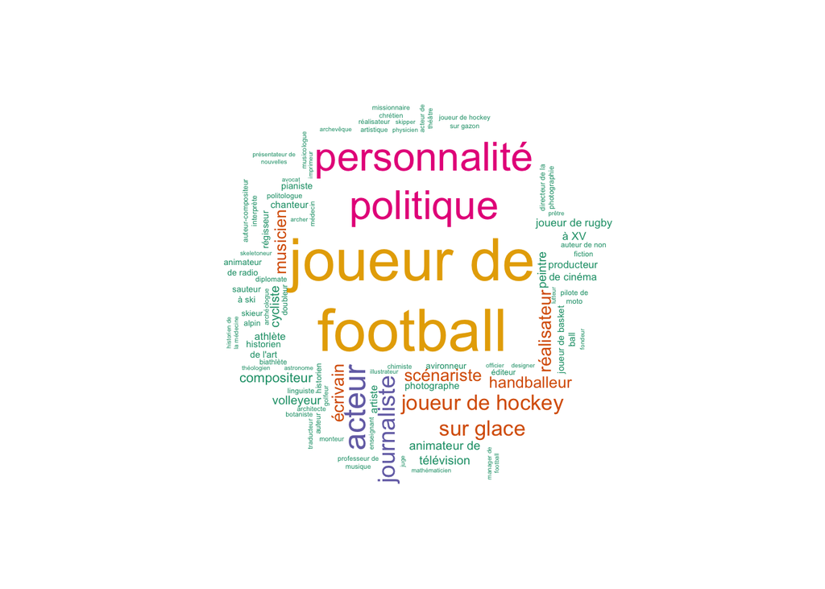

```r
occupationWordcloud(florian)
```

```r
occupationGraph(florian)
```

[interactive chart not shown]